# Exploring the BRFSS data

## Setup

### Load packages

```r
library(ggplot2)
library(dplyr)
library(plotly)
```

### Load data

```r
load("brfss2013.RData")
```

## Part 1: Data

### Many variables, such as age, race, education, as well as variables that measure counts of events (drinks, times eating fruit, etc.) have alternate versions in the Calculated Variables section of the dataset. Review this section prior to choosing variables for analysis.

## Part 2: Research questions

**Research quesion 1:** males vs females in income variable.

## Part 3: Exploratory data analysis

**Research quesion 1:**

```r
df <- brfss2013[,c('income2','sex')]
df$total_sex <- ifelse(df$sex == 'Male' , count(df, sex)[1,2][[1]], count(df, sex)[2,2][[1]])
dff <- df %>%
    group_by(sex, income2 ) %>%
    summarise(count = n(), total = mean(total_sex), percent = count / total)
```

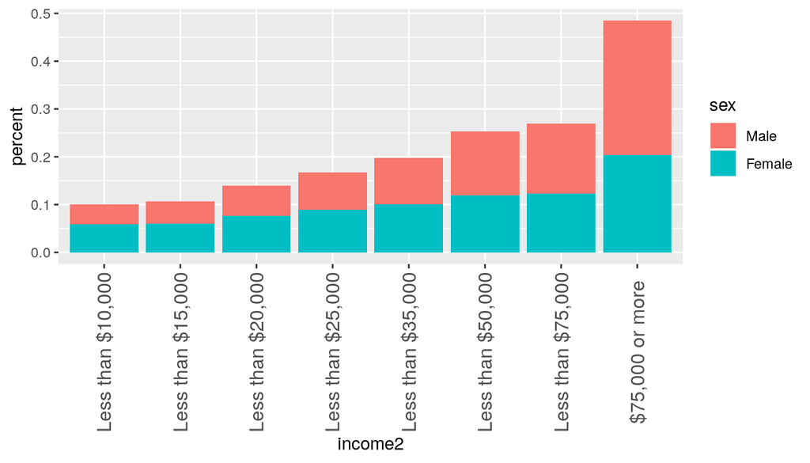

```r
dff <- na.omit(dff)
dff <- select(dff, income2, sex, percent)
x = c('< $10000', '< $15000', '< $25000', '< $35000', '<$50000', '< $75000', '>= 75000')
ggplot(data=dff, aes(x=income2, y=percent, fill=sex)) +
    geom_bar(stat="identity")+#, position=position_dodge()
  theme(axis.text.x  = element_text(angle=90, vjust=0.5, size=12))
```

**Research quesion 2:**

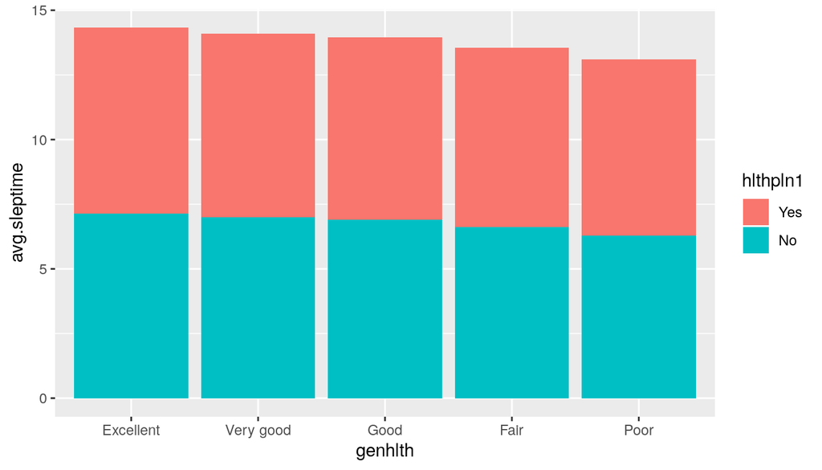

```r
df <- na.omit(brfss2013[,c("genhlth", "hlthpln1", "marital", "sleptim1")])
gp <- df %>%
    group_by(genhlth, hlthpln1) %>%
    summarise(count = n(), avg.sleptime = mean(sleptim1))
ggplot(gp, aes(x = genhlth, y = avg.sleptime, fill=hlthpln1)) + geom_bar(stat="identity")
```

**Research quesion 3:**

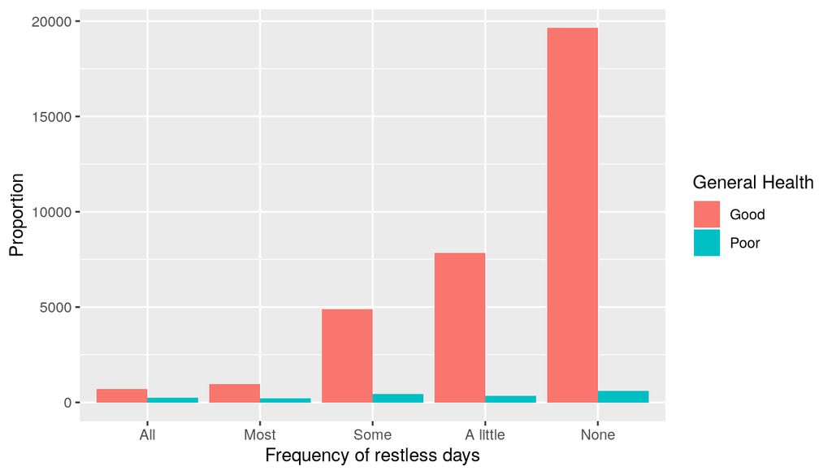

```r
brfss2013_rest_genhlth <- brfss2013 %>% filter(misrstls != "NA") %>% mutate(gen_hlth = ifelse(genhlth == "Poor", "Poor", "Good")) %>% filter(gen_hlth != "NA")
ggplot(brfss2013_rest_genhlth, aes(x = misrstls, fill = gen_hlth)) + geom_bar(position=position_dodge()) + scale_fill_discrete(name = "General Health") + xlab("Frequency of restless days") + ylab("Proportion")
```